# Tugas Mengecek Stasioneritas Data

Aldennabil

2025-09-29

```r
library(ggplot2)
library(tsibble)
library(tseries)
library(MASS)
```

# Input Data

```r
library(rio)
csv <- rio::import("https://github.com/aldennabil/MPDW/raw/refs/heads/main/Kurs%20Jual%20Rataan%20USD%20Fix.xlsx")
dataset <- csv[313:415,2]
str(dataset) # Time = 1, Data = 2
```

```
##  num [1:103] 14369 14308 14433 14383 14356 ...
```

```r
data <- ts(as.numeric(dataset), start = 1, frequency = 1)  # atau start=c(2024,1), frequency=52 untuk mingguan
tibble <- as_tibble(dataset)
data
```

```
## Time Series:
## Start = 1
## End = 103
## Frequency = 1
##   [1] 14369.09 14307.78 14433.41 14383.36 14355.82 14305.97 14454.32 14538.53
##   [9] 14591.60 14586.17 14590.79 14570.49 14491.10 14446.88 14478.63 14485.67
##  [17] 14372.71 14310.60 14319.24 14321.25 14365.47 14320.05 14248.29 14201.46
##  [25] 14261.76 14377.73 14315.83 14309.80 14360.24 14451.90 14438.03 14422.76
##  [33] 14332.91 14335.12 14422.56 14380.55 14416.33 14444.26 14450.50 14411.50
##  [41] 14393.41 14435.42 14443.26 14382.76 14421.95 14425.97 14431.20 14433.21
##  [49] 14424.37 14531.50 14662.35 14751.80 14649.89 14550.19 14764.86 14906.76
##  [57] 14917.22 15056.31 15060.33 15070.58 15070.58 14968.07 14945.36 14846.26
##  [65] 14927.67 14954.20 14971.08 14966.66 15081.84 15275.20 15317.81 15432.98
##  [73] 15603.43 15661.32 15740.71 15723.02 15688.45 15766.04 15729.05 15640.81
##  [81] 15711.97 15683.83 15742.52 15682.42 15523.83 15184.34 15036.61 15035.60
##  [89] 15223.14 15256.91 15290.87 15350.37 15495.09 15456.70 15254.69 15049.88
##  [97] 14953.19 14859.32 14748.58 14810.89 14940.33 15008.07 14989.37
```

## Plot *Time Series*

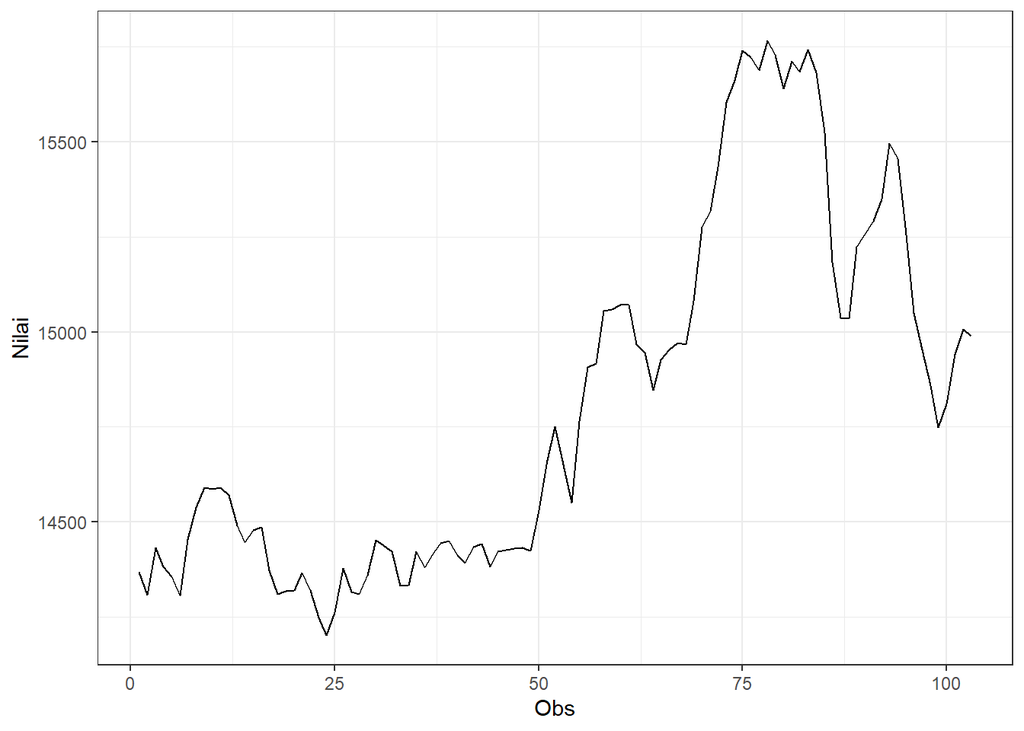

```r
plot_data <- data |> as_tsibble() |>
  ggplot(aes(x = index, y = value)) + geom_line() + theme_bw() +
  xlab("Obs") + ylab("Nilai")
plot_data
```

```r
mean(data)
```

```
## [1] 14808.67
```

Berdasarkan plot time series tersebut, terlihat bahwa data tidak stasioner dalam rataan karena terdapat tren dengan lebar pita bervariasi yang menandakan tidak stasioner dalam ragam juga.

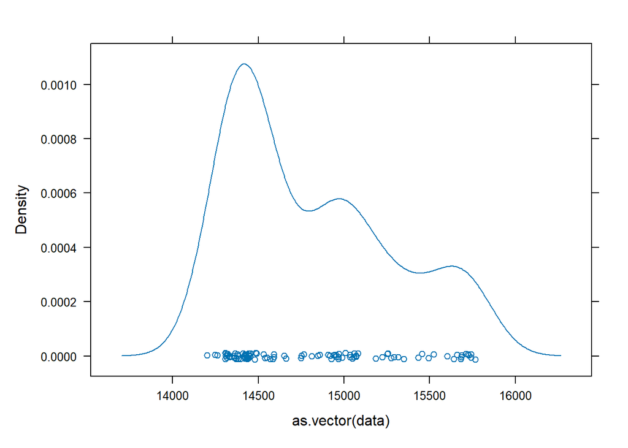

```r
lattice::densityplot(as.vector(data))
```

## Plot ACF

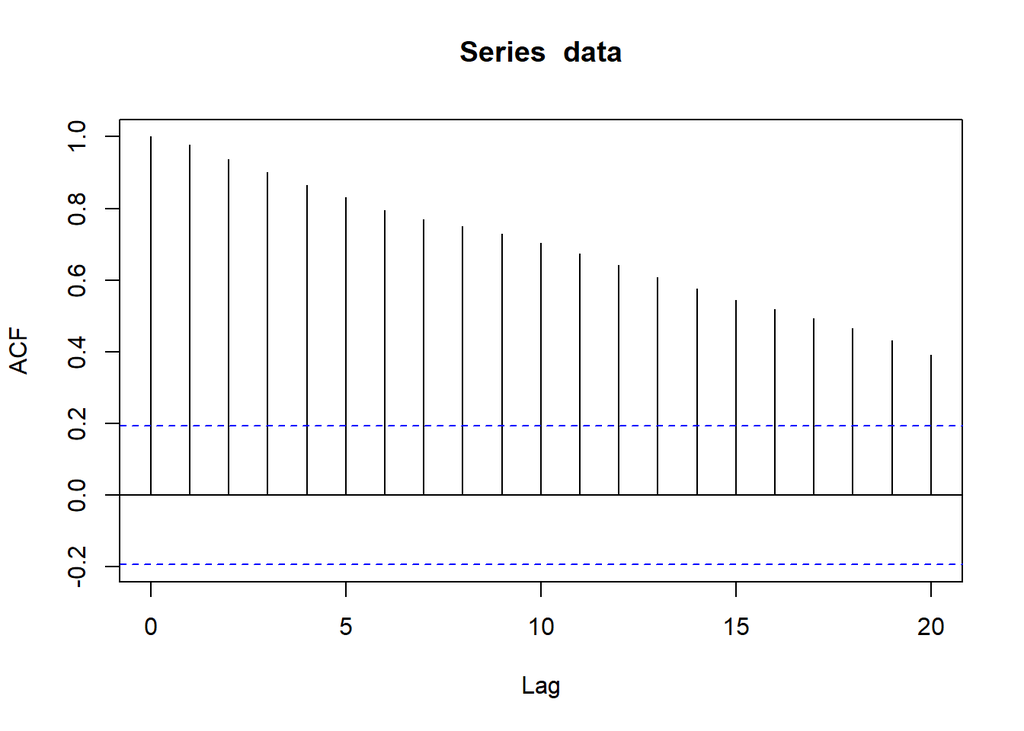

```r
acf(data)
```

Berdasarkan plot ACF, terlihat bahwa plot ACF pada data tersebut menurun secara perlahan (*tails off slowly*) yang menandakan data tidak stasioner dalam rataan

## Uji ADF

```r
tseries::adf.test(data)
```

```
##
##  Augmented Dickey-Fuller Test
##
## data:  data
## Dickey-Fuller = -1.9711, Lag order = 4, p-value = 0.5887
## alternative hypothesis: stationary
```

$H_0$ : Data tidak stasioner dalam rataan

$H_1$ : Data stasioner dalam rataan

Berdasarkan uji ADF tersebut, didapat *p-value* sebesar $0.5887$ yang lebih besar dari taraf nyata 5% dan menandakan bahwa data tidak stasioner dalam rataan. Hal ini sesuai dengan hasil eksplorasi menggunakan plot time series dan plot ACF

## Partisi Data

Partisi data adalah memecah deret waktu menjadi beberapa sub-periode yang lebih homogen (sering disebut piecewise stationary).

- **Tujuan utama:**
  1. **Diagnosa**: membedakan non-stasioner karena **unit root** vs **structural break** dengan melihat plot/ACF/ADF per bagian.
  2. **Pemodelan**: memungkinkan model **per-rezim** atau penambahan **dummy step/pulse/tren** pada titik patah, sehingga parameter tidak “tercampur” antar rezim.
  3. **Transformasi**: menilai kebutuhan **log/Box-Cox** dan **differencing** berdasarkan ragam & level lokal.
  4. **Validasi**: mengecek kestabilan parameter dan performa antar bagian sebelum memutuskan model global terbaik.

### Deteksi Partisi

```r
library(changepoint)
y <- as.numeric(data)  # vektor nilai

cp <- cpt.meanvar(
  y,
  method   = "PELT",
  penalty  = "MBIC",                  # hemat jumlah break
  minseglen = 8                       # ≥ 8–12 utk mingguan
)

cpts(cp)      # indeks break
```

```
## [1] 34 49 72 84 95
```

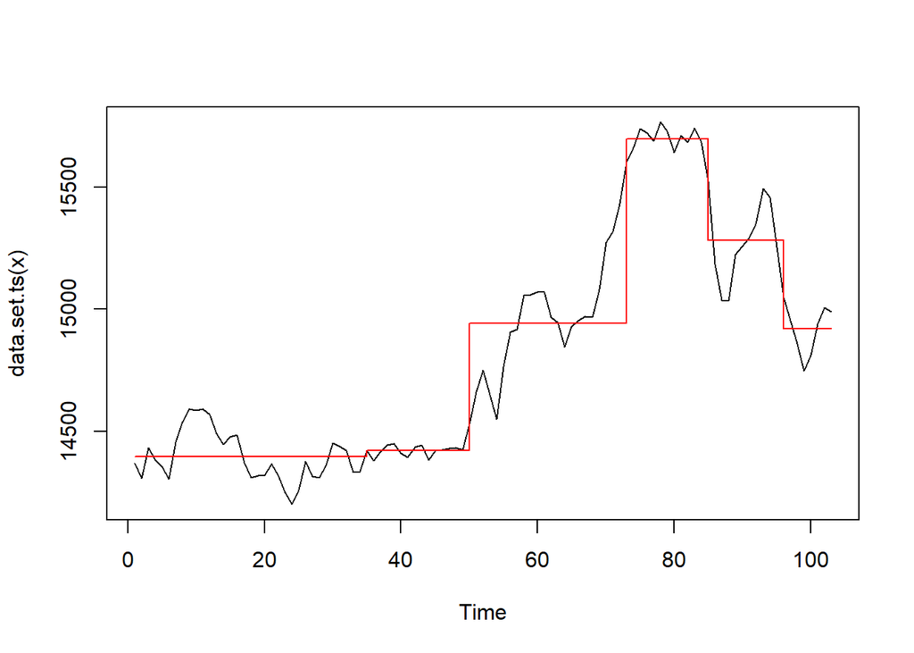

```r
plot(cp)      # plot data + step mean
```

Berdasarkan deteksi tersebut, kita bisa partisi data 34,49,72,84,95. Tapi karena data kita kecil, maka akan seleksi partisi manual menjadi 1-49, 50-80, 81-103.

### Bagian 1

```r
data1 <- data[1:49] |> ts()
mean(data1)
```

```
## [1] 14403.51
```

```r
var(data1)
```

```
## [1] 7466.349
```

#### Plot Time Series

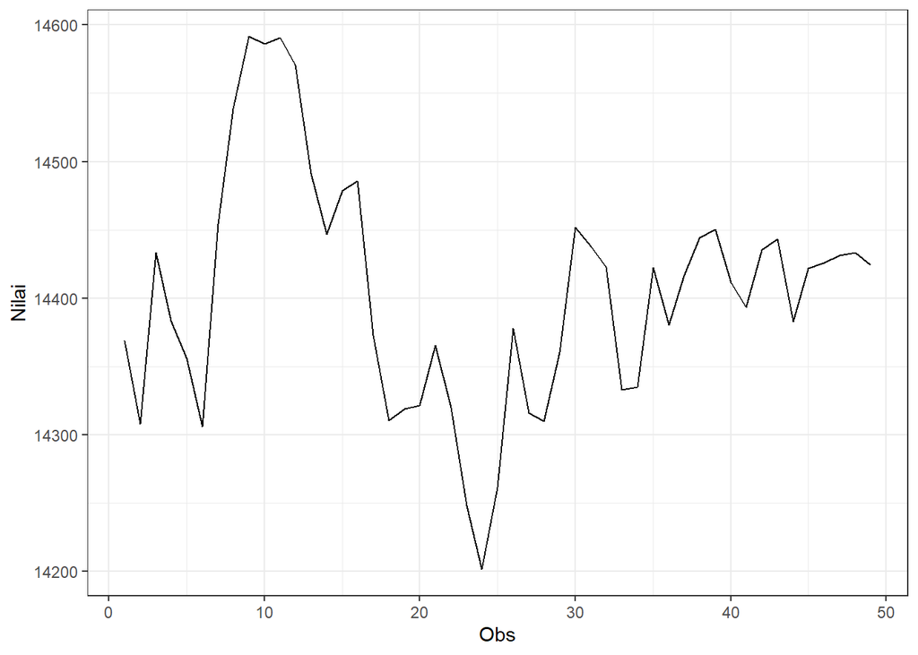

```r
data1 |> as_tsibble() |>
  ggplot(aes(x = index, y = value)) +
  geom_line() + theme_bw() +
  xlab("Obs") + ylab("Nilai")
```

Berdasarkan plot time series tersebut, terlihat bahwa data tidak stasioner dalam rataan dengan lebar pita bervariasi yang menandakan tidak stasioner dalam ragam juga.

#### Plot ACF

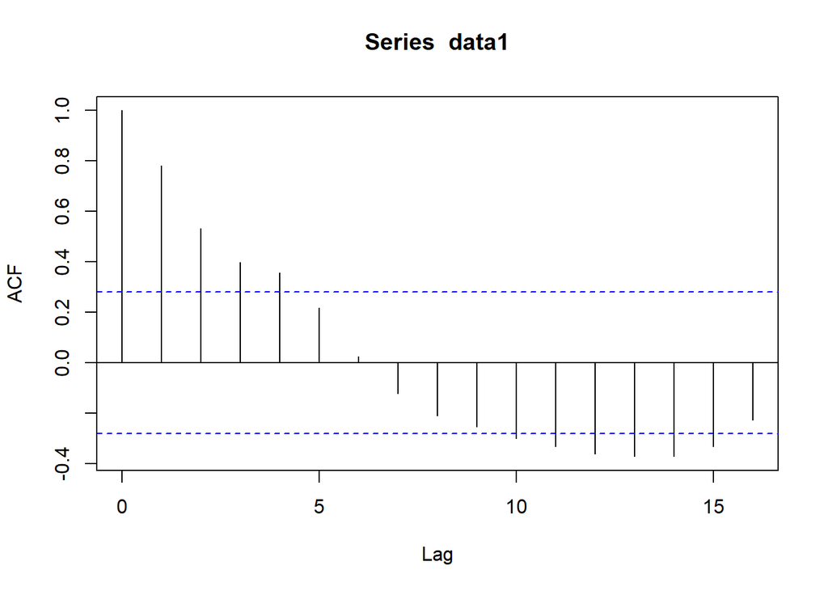

```r
acf(data1)
```

Berdasarkan plot ACF, terlihat bahwa plot ACF pada data tersebut menurun secara (*tails off*) yang menandakan data tidak stasioner dalam rataan dan membentuk pola kosinus

#### Uji ADF

```r
adf.test(data1)
```

```
##
##  Augmented Dickey-Fuller Test
##
## data:  data1
## Dickey-Fuller = -1.8107, Lag order = 3, p-value = 0.65
## alternative hypothesis: stationary
```

$H_0$ : Data tidak stasioner dalam rataan

$H_1$ : Data stasioner dalam rataan

Berdasarkan uji ADF tersebut, didapat *p-value* sebesar $0.65$ yang lebih besar dari taraf nyata 5% dan menandakan bahwa data tidak stasioner dalam rataan. Hal ini sesuai dengan hasil eksplorasi menggunakan plot time series dan plot ACF

### Bagian 2

```r
data2 <- data[50:80] |> ts()
mean(data2)
```

```
## [1] 15136.53
```

```r
var(data2)
```

```
## [1] 150448.5
```

#### Plot Time Series

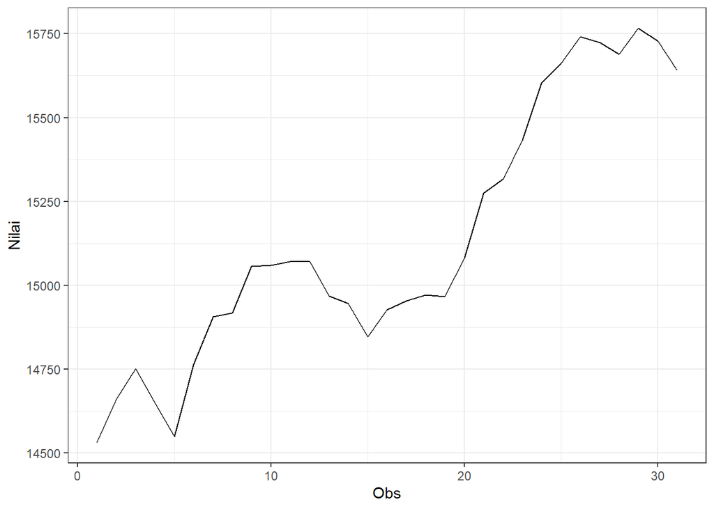

```r
data2 |> as_tsibble() |>
  ggplot(aes(x = index, y = value)) +
  geom_line() + theme_bw() +
  xlab("Obs") + ylab("Nilai")
```

Berdasarkan plot time series tersebut, terlihat bahwa data yang tidak stasioner, dan tidak stasioner dalam ragam karena memiliki lebar pita yang cenderung tidak sama/bervariasi

#### Plot ACF

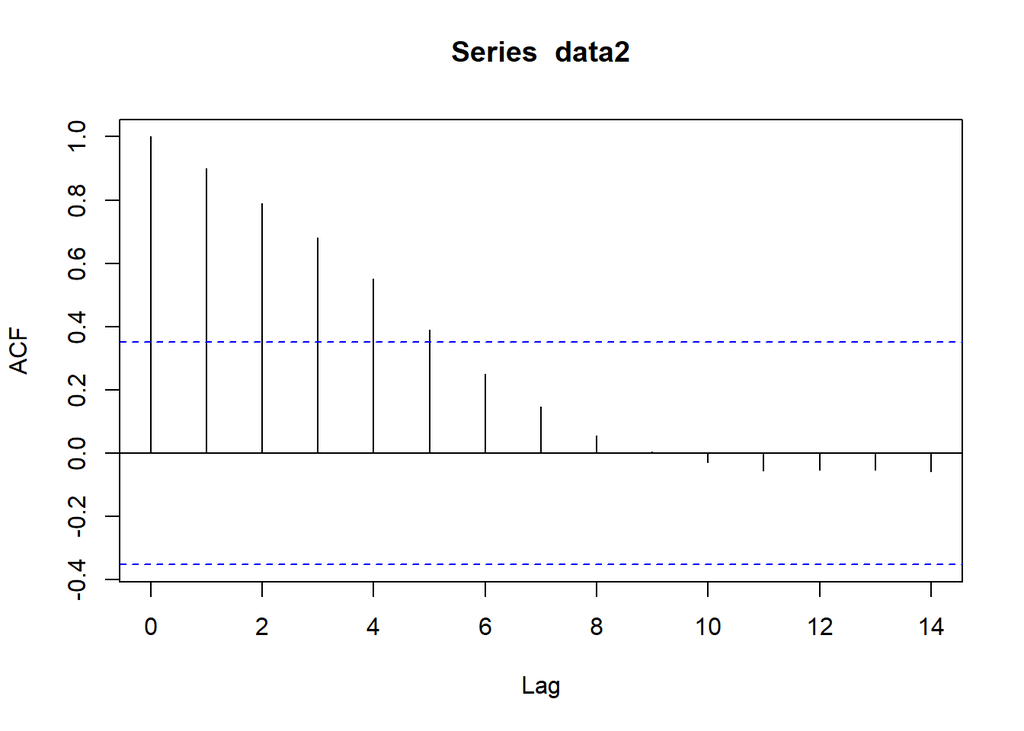

```r
acf(data2)
```

Berdasarkan plot ACF, terlihat bahwa plot ACF pada data tersebut *tails off* yang menunjukkan data tidak stasioner dalam rataan

#### Uji ADF

```r
adf.test(data2)
```

```
##
##  Augmented Dickey-Fuller Test
##
## data:  data2
## Dickey-Fuller = -2.49, Lag order = 3, p-value = 0.3841
## alternative hypothesis: stationary
```

$H_0$ : Data tidak stasioner dalam rataan

$H_1$ : Data stasioner dalam rataan

Berdasarkan uji ADF tersebut, didapat *p-value* sebesar $0.3841$ yang lebih besar dari taraf nyata 5% dan menandakan bahwa data tidak stasioner dalam rataan. Hal ini sesuai dengan hasil eksplorasi menggunakan plot time series dan plot ACF

```r
data3 <- data[81:103] |> ts()
mean(data3)
```

```
## [1] 15229.94
```

```r
var(data3)
```

```
## [1] 93428.42
```

#### Plot Time Series

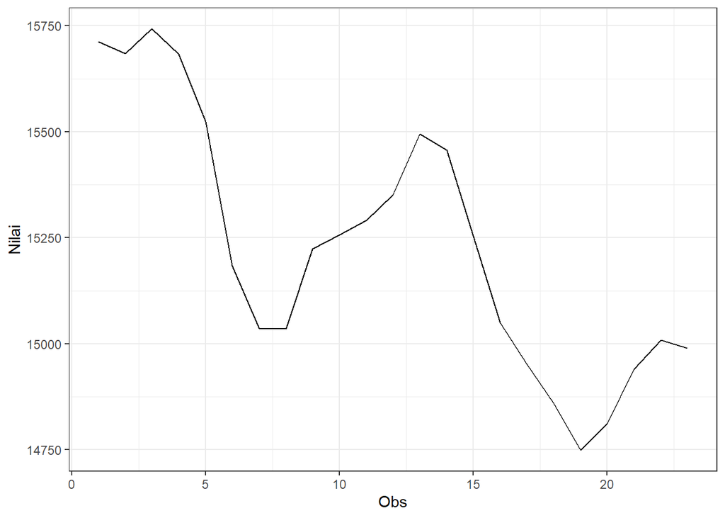

```r
data3 |> as_tsibble() |>
  ggplot(aes(x = index, y = value)) +
  geom_line() + theme_bw() +
  xlab("Obs") + ylab("Nilai")
```

Berdasarkan plot time series tersebut, terlihat bahwa data tidak stasioner dalam rataan karena masih terdapat tren pada data, namun cenderung stasioner dalam ragam karena memiliki lebar pita yang mungkin sama

#### Plot ACF

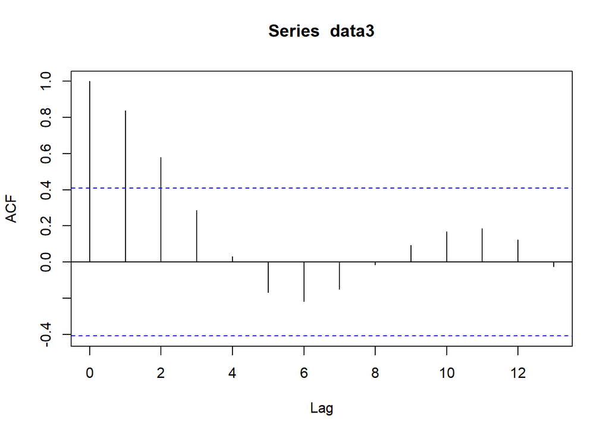

```r
acf(data3)
```

Berdasarkan plot ACF, terlihat bahwa plot ACF pada data tersebut menurun (*tails off*) yang menandakan data tidak stasioner dalam rataan serta membentuk pola kosinus

#### Uji ADF

```r
adf.test(data3)
```

```
##
##  Augmented Dickey-Fuller Test
##
## data:  data3
## Dickey-Fuller = -3.1058, Lag order = 2, p-value = 0.1511
## alternative hypothesis: stationary
```

$H_0$ : Data tidak stasioner dalam rataan

$H_1$ : Data stasioner dalam rataan